# Practical Machine Learning Project: Quantifying the good performance of physical activity

Alberto Vicens

27/4/2019

```r
knitr::opts_chunk$set(echo = TRUE, eval = TRUE, cache = TRUE, autodep = TRUE, cache.path = "cache/", fig.path = "figures/", warning = FALSE)
```

## Introduction

One thing that people regularly do is quantify how much of a particular activity they do, but they rarely quantify how well they do it. In this project, I will predict if barbell lifts are done correctly and incorrectly. using data from several accelerometers in 6 participants.

## Getting data

To built and test a predictive model, I will be to use data from accelerometers on the belt, forearm, arm, and dumbell of 6 participants. This data are freely accesible in the webpage of [Human activity recognition](http://groupware.les.inf.puc-rio.br/har). I download the training and test datasets there are provided.

```r
urlTrain<-"http://d396qusza40orc.cloudfront.net/predmachlearn/pml-training.csv"
urlTest<-"http://d396qusza40orc.cloudfront.net/predmachlearn/pml-testing.csv"

if(!file.exists("pml-training.csv")){
  download.file(urTrain, destfile ="pml-training.csv")
}

if(!file.exists("pml-testing.csv")){
  download.file(urTest, destfile ="pml-testing.csv")
}
```

```r
har<-read.csv("pml-training.csv", header = T)
quiz<-read.csv("pml-testing.csv", header = T)
```

## Cleaning data

I noticed that multiple columns contain a lot of missing data and these are informative. I thus filtered those columns containing > 95% of missing data.

```r
#Getting the percentage of missing values per colum in training dataset
NApercTrain <- sapply(har, function(df) {sum(is.na(df)==TRUE)/length(df)})

#Removing columns with >95% missing values
har<-har[,NApercTrain < 0.95]
quiz<-quiz[,NApercTrain < 0.95]

sum(is.na(har)==TRUE)
```

```
## [1] 0
```

I also removed columns with varianze near zero, as these variable provide little information for model building.

```r
nzv<-nearZeroVar(har)
har<-har[,-nzv]
quiz<-quiz[,-nzv]
```

Lastly, I took off the “X”, “Individual” and “timestamp” columns for being uninformative.

```r
har<-har[,-(1:6)]
quiz<-quiz[,-(1:6)]
rbind(har=dim(har), quiz = dim(quiz))
```

```
##       [,1] [,2]
## har  19622   53
## quiz    20   53
```

```r
library(caret)
set.seed(360)
inTrain<-createDataPartition(y=har$classe,p = 0.6, list = FALSE)
training<-har[inTrain,]
testing<-har[-inTrain,]
rbind(Training=dim(training), Testing=dim(testing))
```

```
##           [,1] [,2]
## Training 11776   53
## Testing   7846   53
```

## Building predictive models

I built predictive models using *Random Forest* and *Boosting* methods. I decided to apply these methods because they are the most widely used methods in machine learning and because they fit relatively well, with very little tunning required.

### Random forest

```r
set.seed(1211)
#Train control by cross validation
controlRF<-trainControl(method = "cv", number = 3, verboseIter = FALSE)

set.seed(3232)
#Model building
rfModFit<-train(classe ~., data = training, method = "rf", trControl = controlRF, verbose = FALSE)

rfModFit$finalModel
```

```
##
## Call:
##  randomForest(x = x, y = y, mtry = param$mtry, verbose = FALSE)
##                Type of random forest: classification
##                      Number of trees: 500
## No. of variables tried at each split: 27
##
##         OOB estimate of  error rate: 0.92%
## Confusion matrix:
##      A    B    C    D    E class.error
## A 3340    5    2    0    1 0.002389486
## B   23 2244   11    1    0 0.015357613
## C    0   11 2036    7    0 0.008763389
## D    0    1   28 1897    4 0.017098446
## E    0    0    6    8 2151 0.006466513
```

I then evaluate the model with the test dataset to estimate the accuracy.

```r
rfTestPred<-predict(rfModFit, testing)

rfTestCM<-confusionMatrix(testing$classe,rfTestPred)
rfTestCM$overall
```

```
##       Accuracy          Kappa  AccuracyLower  AccuracyUpper   AccuracyNull
##      0.9904410      0.9879062      0.9880322      0.9924740      0.2861331
## AccuracyPValue  McnemarPValue
##      0.0000000            NaN
```

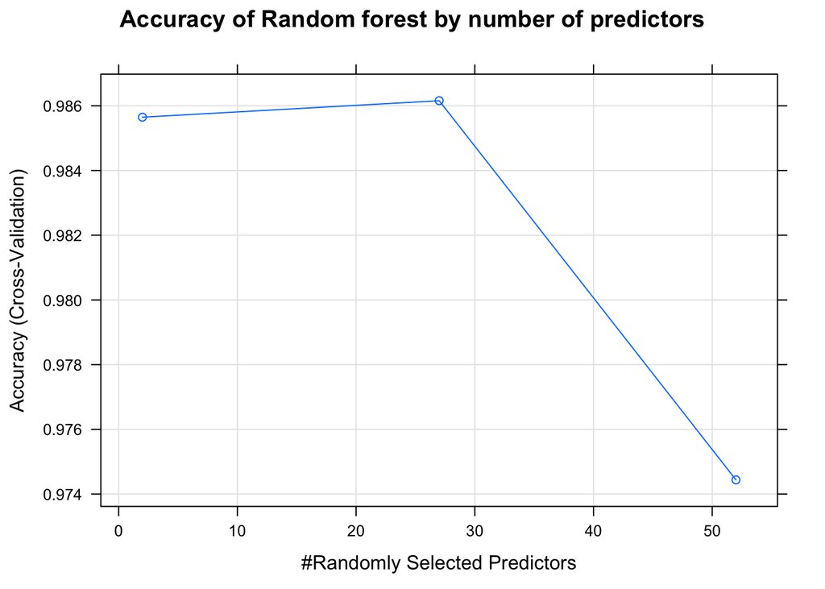

```r
plot(rfModFit, main ="Accuracy of Random forest by number of predictors")
```

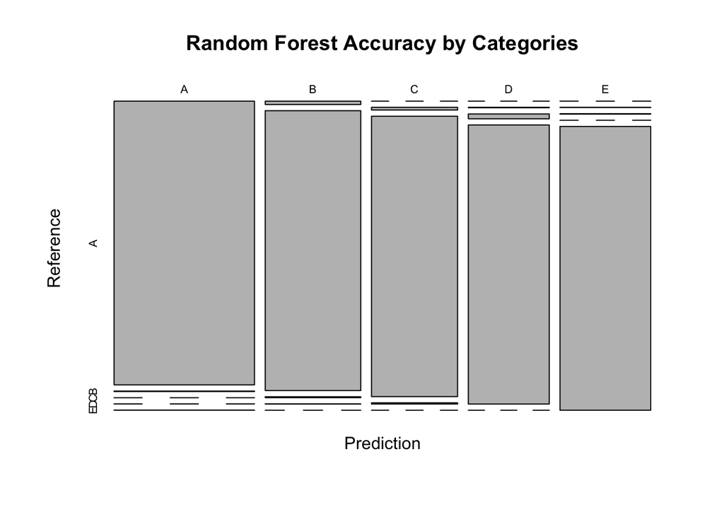

```r
plot(rfTestCM$table, main = "Random Forest Accuracy by Categories")
```

### Generalized Boosting

```r
set.seed(4343)
controlGBM<-trainControl(method="repeatedcv",number=5, repeats=1)
bstModFit<-train(classe ~ ., training, method = "gbm", verbose = FALSE,
                 trControl = controlGBM)
bstModFit$finalModel
```

```
## A gradient boosted model with multinomial loss function.
## 150 iterations were performed.
## There were 52 predictors of which 52 had non-zero influence.
```

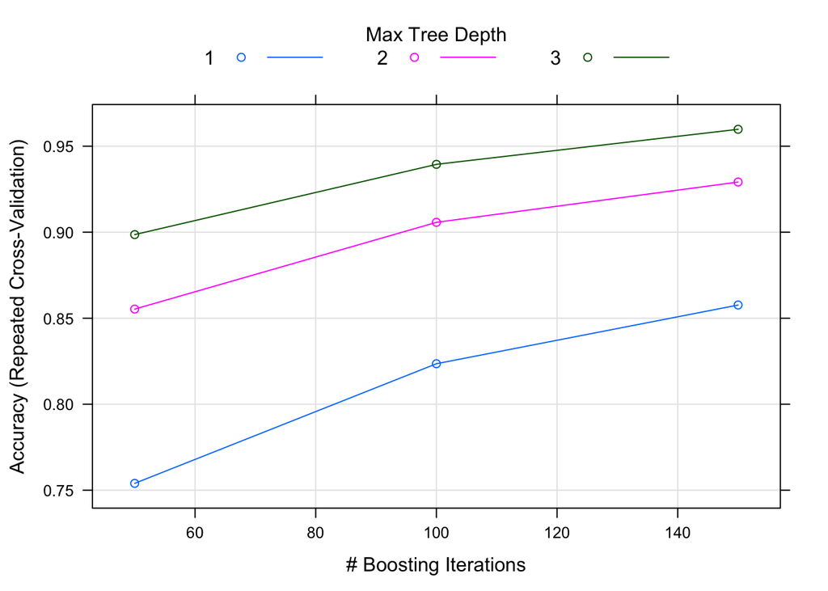

```r
plot(bstModFit)
```

```r
bstTestPredict<-predict(bstModFit,testing)
bstTestCM<-confusionMatrix(bstTestPredict, testing$classe)
bstTestCM$overall
```

```
##       Accuracy          Kappa  AccuracyLower  AccuracyUpper   AccuracyNull
##   9.604894e-01   9.500040e-01   9.559408e-01   9.646918e-01   2.844762e-01
## AccuracyPValue  McnemarPValue
##   0.000000e+00   3.469511e-11
```

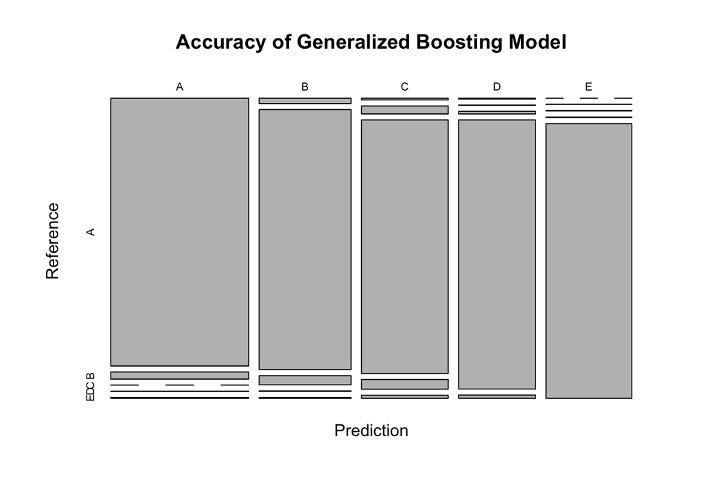

```r
plot(bstTestCM$table, main = "Accuracy of Generalized Boosting Model")
```

```r
bstValidPred<- predict(bstModFit, quiz)
quizOut<-cbind(Question=seq(1:20), Response = as.character(bstValidPred))
quizOut
```

```
##       Question Response
##  [1,] "1"      "B"
##  [2,] "2"      "A"
##  [3,] "3"      "B"
##  [4,] "4"      "A"
##  [5,] "5"      "A"
##  [6,] "6"      "E"
##  [7,] "7"      "D"
##  [8,] "8"      "B"
##  [9,] "9"      "A"
## [10,] "10"     "A"
## [11,] "11"     "B"
## [12,] "12"     "C"
## [13,] "13"     "B"
## [14,] "14"     "A"
## [15,] "15"     "E"
## [16,] "16"     "E"
## [17,] "17"     "A"
## [18,] "18"     "B"
## [19,] "19"     "B"
## [20,] "20"     "B"
```

**Note**: The dataset used in this project is a courtesy of “Ugulino, W.; Cardador, D.; Vega, K.; Velloso, E.; Milidiu, R.; Fuks, H. Wearable Computing: Accelerometers’ Data Classification of Body Postures and Movements”